# Ponto 7 - Amostragem Casual Simples e Casual Estratificada

Gabriel Agostini Orso

Data de Publicação

28 de março de 2026

# 1 Preâmbulo

**AvisoAviso**

Antes de prosseguir, o leitor deve estar ciente de que o material aqui utilizado foi elaborado com o único objetivo de estudo pessoal, portanto muitas passagens são fruto de conhecimento e interpretação pessoal. No entanto, ainda assim esse texto faz uso extensivo da literatura científica apresentada ao fim do trabalho, mas **por ser material pessoal de estudo** muitas passagens não fazem a devida citação das obras consultadas, tal qual se esperaria de trabalhos científicos.

Além isso, não foram utilizadas ferramentas de inteligência artificial como *chatGPT*, *Gemini*, *Manus* ou outras para a construção do texto. Toda a sequência lógica, exemplos, entendimentos e escrita são de responsabilidade do autor.

Com essas condições em mente, espero que esse material seja oportuno. Boa leitura.

# 2 Introdução

A amostragem constitui uma etapa essencial nos inventários florestais e na obtenção de parâmetros populacionais com base em subconjuntos da floresta, especialmente quando o censo completo é inviável. Nesse contexto, dois dos planos amostrais mais utilizados são a Amostragem Casual Simples (ACS) e a Amostragem Casual Estratificada (ACE), ambos fundados na Teoria da Pesquisa por Amostragem (TPA). Diferente da Teoria da Amostragem Clássica (TAC), que parte de pressupostos assintóticos e da existência de populações infinitas, a TPA trabalha com populações finitas e enumeráveis, fornecendo estimadores exatos, não viesados e consistentes, independentemente do tamanho amostral.

A obra de Cochran (1977) é amplamente reconhecida como referência nesse campo, por desenvolver de forma sistemática os principais estimadores baseados em planos amostrais bem definidos. A partir da ACS, plano elementar da TPA, são construídos os demais métodos, como a ACE, que incorpora o conhecimento prévio da estrutura da população para obter maior precisão estatística por meio da estratificação.

Neste trabalho, apresenta-se a fundamentação teórica da ACS e da ACE, detalhando-se suas propriedades estatísticas, como estimadores de média, total, variância, erro de amostragem e intensidade amostral. Também são abordadas as implicações práticas desses métodos no manejo florestal, destacando o papel da estratificação para redução de erros, bem como tecnologias emergentes que têm potencializado a eficiência dos inventários florestais, como aplicativos móveis, sensores remotos e modelos de predição assistidos por inteligência artificial.

# 3 Fundamentação Teórica

A fundamentação estatística das amostragens aleatórias simples e estratificada, ou de maneira mais geral da teoria da amostragem, vem de um ramo chamado de Teoria da Pesquisa por Amostragem (TPA), e possui algumas diferenças de outra linhas da estatística que trabalha com amostras, chamada de Teoria da Amostragem Clássica (TAC).

## 3.1 2.1 Abordagem Clássica (Teorica da Amostragem Clássica)

A TAC é baseada em sua essência em problemas chamados de população infinita, e, portanto, está fortemente amparada em teoremas assintóticos, como a Lei dos Grandes Números, Teoria Central do Limite, e seus consequentes estimadores assintóticos, *i.e.*, com propriedades válidas quando $n \to \infty$, além de presumir uma distribuição de probabilidade para a amostra em diversos contextos. É dessa abordagem que são construídos os estimadores para análises de experimentos controlados, por exemplo.

## 3.2 2.2 Teoria da Pesquisa por Amostragem (TPA)

### 3.2.1 Ideia de Populações Finitas

Por outro lado, a TPA não se preocupa com a distribuição da variável aleatória, e assume por construção a existência de uma população finita, enumerável. Por consequência disso, a maioria dos estimadores dessa linha de amostragem são exatos, *i.e.*, sem viés e consistentes para qualquer tamanho de amostra $n$.

## 3.3 Estimadores, Viés e Consistência

As principais quantidades de interesse ao estudar uma população são a média e o total populacional, porém outras medidas são oportunamente tratadas na teoria, como a razão entre variáveis e medidas de proporção. Para obter tais quantidades, se faz o uso de subconjuntos dessa população, chamada *amostra*, e a partir dessa amostra tais quantidades são estimadas.

Assim se criam os estimadores das quantidades populacionais. A maneira de encontrar esses estimadores é totalmente dependente do plano amostral utilizado, ou seja, de *como essa população será amostrada*.

Dois princípios de grande importância são utilizados para avaliar estimadores: o viés e a consistência. Um estimador é considerado **não viesado** se a média de seus valores, tomados sobre todas as possíveis amostras, é exatamente igual ao valor paramétrico. Em outras palavras, se a esperança matemática do estimador é o valor populacional.

Um estimador será chamado de **consistente** se o estimador se torna exatamente igual ao valor populacional quando $N=n$, isto é, quando a amostra é composta de toda a população.

# 4 Amostragem Casual Simples

## 4.1 Notação Utilizada e Quantidades de Interesse

O plano amostral mais simples, do qual todos os demais são derivados, é a amostragem casual simples (ACS). As duas principais quantidades e seus respectivos estimadores são a média e o total (Tabela 1). Frequentemente nesse ramo da estatística as quantidades populacionais são representadas por letras latinas maiúsculas, como $Y$ e $\bar Y$, enquanto estimadores por letras minúsculas, como $\bar y$.

Tabela 1: Parâmetros e estimadores de interesse na amostragem casual simples.

|  | População | Amostra |
| --- | --- | --- |
| Média | $\bar Y = {1 \over N}\displaystyle\sum_{i=1}^N y_i$ | $\bar y = {1 \over n}\displaystyle\sum_{i=1}^n y_i$ |
| Total | $Y = \displaystyle\sum_{i=1}^N y_i$ | $N\bar y = \displaystyle\sum_{i=1}^n y_i$ |

Legenda: $\bar Y$ e $Y$ são a média e total populacionais; $\bar y$ e $N \bar y$ são os respectivos estimadores. $N$ e $n$ são o tamanho da população e amostra, respectivamente, e $y_i$ é a i-ésima observação da variável aleatória de interesse.

## 4.2 Princípio da mesma chance de escolha de U.A.s

A ideia central do método é a de que qualquer **unidade amostral** (U.A.), isto é, cada elemento $y_i$ que se deseja mensurar/observar, possui a mesma probabilidade de escolha, tal que $P(Y=y_i)=1/N$.

Seja $y_1,y_2,\ldots,y_n$ um subconjunto de tamanho $n$ dessa população (Figura 1). Tal subconjunto é uma *amostra* da população de tamanho $N$. Perceba que, se cada U.A. possui mesma probabilidade, então existem ($_NC_n = \binom{N}{n}$ possíveis amostras de tamanho $n$ que podem ser obtidas, tal que

$$_NC_n = \binom{N}{n} = {N! \over n!(N-n)!}
\tag{1}$$

Portanto a probabilidade de uma amostra de tamanho n qualquer ser selecionada é de ${1 \over \binom{N}{n}}$ para qualquer amostra, e isso é muito importante para conferir o caráter não-viesado dos estimadores.

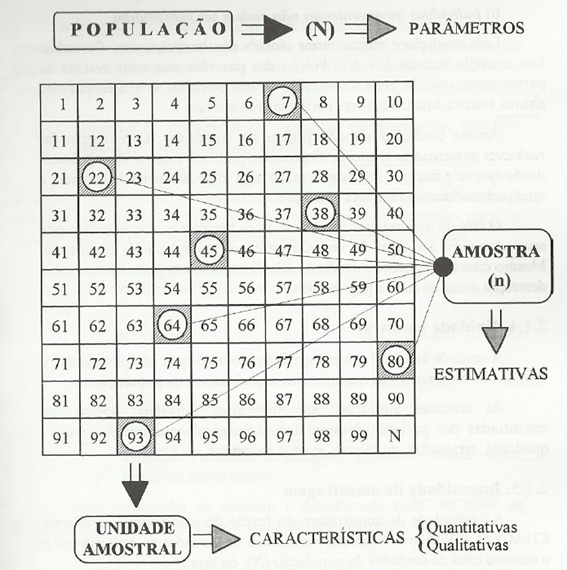

Figura 1: Organização estrutural de uma população, amostra e unidade amostral.

## 4.3 Média Amostral

O primeiro estimador desenvolvido para a ACS foi o estimador da média populacional. Tomando-se uma amostra qualquer e aplicando-se a média $\bar y$ dessa amostra, então essa é apenas uma de $_NC_n$ médias possíveis de serem obtidas. Como $N$ é finito e, portanto, enumerável, então existe um conjunto finito de valores possíveis para $\bar y$. Isso caracteriza $\bar y$ como uma distribuição discreta de probabilidade.

A média amostral possui as duas características desejáveis de estimadores: é não-viesada e é consistente. Como $\bar y$ é discreta, sua esperança é dada na forma

$$E[\bar y] = \displaystyle \sum_{k=1}^{_NC_n} \bar y_k . p(\bar y_k)$$

Onde $E[\cdot]$ é o operador de esperança, $k$ é o índice da possível amostra: $k=1,2,\ldots,_NC_n$ , e $p(\bar y_k)$ é a probabilidade de observar $\bar y_k$.

Como todas as amostras são igualmente prováveis, isto é, $p(\bar y_k )= {1 \over \binom{N}{n}} \forall \enspace k \in 1,2,\ldots ,_NC_n$, então

$$E[\bar y] = p(\bar y_k) \displaystyle \sum_{k=1}^{_NC_n} \bar y_k$$

$\bar y$ possui as características desejáveis de estimadores, pois é não-viesado e é consistente. A propriedade de não-viesado é aferida ao estimador se $E[\bar y] = \bar Y$

**Prova**

Quer-se mostrar que $E[\bar y] = \bar Y$

$$E[\bar y] = p(\bar y_k) . \displaystyle \sum_{k=1}^{_NC_n} \bar y_k = {1 \over \binom{N}{n}}\displaystyle \sum_{k=1}^{_NC_n} {(y_{k1} + y_{k2} + \cdots + y_{kn}) \over n}$$

Note que $y_{ki}$ é a $i$-ésima unidade amostral da *$k$-ésima possível amostra*. Expandindo o somatório, tem-se que cada unidade amostral estará presente em exatas $\binom{N-1}{n-1}$ amostras. Assim

$$\begin{aligned}
E[\bar y] &= {1 \over \binom{N}{n}}{\binom{N-1}{n-1} (y_1 + y_2 + \cdots + y_N) \over n} = \\
&= {1 \over {N! \over n!(N-n)!}} {{(N-1)! \over (n-1)!(N-n)!}\displaystyle\sum_{i=1}^N y_i \over n} \\
&= {n!(N-n)! \over N!} {(N-1)! \over (n-1)!(N-n)!n} \displaystyle\sum_{i=1}^N y_i \\
&= {n(n-1)!(N-1)! \over N(N-1)!(n-1)!n} \displaystyle\sum_{i=1}^N y_i \\
&= {1 \over N} \displaystyle\sum_{i=1}^N y_i = \bar Y
\end{aligned}$$

Isso conclui a prova de que o valor esperado do estimador $\bar y$ é a média populacional $\bar Y$. Veja que esse caráter não-viesado só ocorre pois $p(\bar y_k) = 1 / \binom{N}{n}$ para qualquer amostra possível. Na prática, isso significa que a ACS só possui estimadores válidos se a amostra for tomada de forma aleatória, com mesma chance para qualquer unidade amostral. Essa forma de seleção da amostra é o coração da Teoria da Pesquisa por Amostragem (TPA), e aqui mais especificamente da ACS. Se a amostra não for tomada de forma aleatória, os estimadores não serão mais adequados.

A prova da falta de viés é extremamente importante não só para ACS, mas também para todos os demais estimadores e planos amostrais subsequentes. O estimador do total populacional, por exemplo, utiliza a prova anterior para mostrar seu caráter não-viesado:

Quer-se mostrar que $E[N \bar y]=Y$

$$E[N\bar y] = N. E[\bar y] = N . \bar Y = N {1 \over N} \displaystyle\sum_{i=1}^N y_i = \displaystyle \sum_{i=1}^N y_i = Y$$

Isso conclui a prova.

Outra propriedade importante que o estimador da média possui é a da consistência. Como já definido, um estimador é considerado consistente quando seu valor atinge exatamente o valor paramétrico quando $n=N$, ou seja

$$\bar y = {1 \over n} \displaystyle \sum_{i=1}^n y_i \qquad n \to N \qquad {1 \over N} \displaystyle \sum_{i=1}^N y_i = \bar Y$$

Antes de prosseguir, é apropriado citar um resultado útil ao trabalhar com somas em amostras e suas equivalências na população.

Veja que

$$\begin{aligned}
E[\bar y] &= \bar Y \\
&= E\left[{1 \over n} \displaystyle \sum_{i=1}^n y_i \right] = {1 \over N} \displaystyle\sum_{i=1}^N y_i \\
&= {1 \over n} E\left[\displaystyle\sum_{i=1}^n y_i \right] = {1 \over N} \displaystyle\sum_{i=1}^N y_i \\
&= E\left[\displaystyle\sum_{i=1}^n y_i \right] = {n \over N} \displaystyle\sum_{i=1}^N y_i
\end{aligned}$$

Em outras palavras, podemos escrever que

$$E\left[\begin{array}{c} \text{Soma na} \\ \text{Amostra} \end{array} \right] = {\text{nº na amostra} \over \text{nº na população}} \left[\begin{array}{c} \text{Soma na} \\ \text{População} \end{array} \right]
\tag{2}$$

Ou seja, a esperança de uma soma na amostra é proporcional à soma na população. Esse resultado é bastante oportuno para obtenção dos estimadores subsequentes, e será chamado de Resultado 2.

## 4.4 Variância da Média Amostral

Veja que normalmente apenas uma amostra de tamanho $n$ é realizada, portanto apenas uma média $\bar y$ de diversas possíveis. Essa condição torna $\bar y$ uma variável aleatória que possui uma incerteza (variabilidade) associada. Tal incerteza possui nome e representa a **variância da média amostral**, denotada por $V[\bar y]$ ou por $S^2_{\bar y}$. Aqui será padronizado $V[\bar y]$ para se referir à variância da média amostral.

$$V[\bar y] = {S^2 \over n}\left({N-n \over N} \right) = {S^2 \over n}( 1 - f)
\tag{3}$$

Onde $V[\cdot]$ representa o operador de variância, $S^2$ é a variância populacional das observações $y_i$, e $f= {n \over N}$ representa a fração amostral.

Note ainda que a variância é o segundo momento em torno da média da distribuição, isso quer dizer que

$$V[\bar y] = E\left[(\bar y - \bar Y)^2 \right]
\tag{4}$$

A variância da média amostral informa o quanto a média amostral varia, ou quão incerta é sua estimativa. A divisão por $n$ deixa claro que, conforme aumenta o tamanho da amostra, menor será o valor de $V[\bar y]$. A multiplicação por $\left({N-n \over N}\right) = (1 - f)$ é conhecida por correção de populações finitas. Tal correção é um dos divisores de água entre Teoria da Amostragem Clássica (TAC) e Teoria da Pesquisa por Amostragem (TPA).

Pela abordagem da TAC, a Lei Forte de Kolmogorov aplicada ao Teorema Central do Limite resultam que a média de uma sequência de variáveis aleatórias independentes e identicamente distribuídas possui variância $S^2 \over n$, porém tal valor só é atingido assintoticamente, quando $n \to \infty$.

O termo adicional $(1-f)$ obtido a partir da TPA é exatamente a correção necessária para que $V[\bar y]$ seja não viesado mesmo para pequenas amostras, pois a maioria dos estimadores obtidos pela TPA são resultados exatos, e não assintóticos. Ainda assim, é notável que, conforme $n \to N$, cada vez mais as duas teorias se aproximam. Na área florestal, Péllico Netto & Brena (1997) adotam um valor referencial de $f=0.02$ (Cochran utiliza $0.05$) para definir população finita de infinita. Em sua essência, populações infinitas fazem uso de estimadores com propriedades assintóticas, *i.e.*, seguem o caminho da TAC, que possuem fórmulas mais simplificadas. Aqui, no entanto, será dado ênfase aos estimadores obtidos pela TPA.

Note que $V[\bar y]$ faz uso da variância populacional das observações $S^2$. A obtenção dessa variância difere levemente da variância paramétrica $\sigma^2$.

$$\sigma^2 = {\displaystyle\sum_{i=1}^N (y_i - \bar Y)^2 \over N} \qquad \qquad S^2 = {\displaystyle \sum_{i=1}^N (y_i - \bar Y)^2 \over N-1}$$

Embora $\sigma^2$ seja a fórmula para estimar corretamente a variância da população, Cochran (1977) faz uso de $S^2$ para os cálculos, pois isso torna alguns resultados com expressões matemáticas mais simplificadas. Os resultados dos estimadores futuros não devem possuir diferença ao usar uma outra formulação (COCHRAN, 1977).

**Prova do Resultado 3**:

Seja a soma simples

$$\displaystyle \sum_{i=1}^N (y_i - \bar Y) = \displaystyle\sum_{i=1}^{n} y_i - \displaystyle\sum_{i=1}^{n} \bar Y = {n \over n} \displaystyle\sum_{i=1}^{n} y_i - n \bar Y = n \bar y - n \bar Y$$

Portanto

$$\displaystyle\sum_{i=1}^{n} (y_i - \bar Y) = n(\bar y - \bar Y)$$

Elevando tudo ao quadrado, temos

$$[n(\bar y - \bar Y)]^2 = n^2(\bar y - \bar Y)^2 = \left[ \displaystyle\sum_{i=1}^{n} (y_i - \bar Y) \right]^2$$

Fazendo uso da propriedade da soma de quadrados, tem-se que $(\sum x)^2 = \sum x^2 + 2 \sum_{i<j}\sum x_ix_j$, portanto

$$n^2(\bar y - \bar Y)^2 = \displaystyle\sum_{i=1}^{n} (y_i - \bar Y)^2 + 2 \displaystyle\sum_{i < j} \displaystyle\sum (y_i - \bar Y)(y_j - \bar Y)$$

Agora aplicando a esperança, usa-se o Resultado 4

$$E\left[n^2(\bar y - \bar Y)^2\right] = n^2E\left[(\bar y - \bar Y)^2\right] = n^2 V[\bar y]$$

$$\begin{aligned}
n^2 V\left[\bar y\right] &= E \left[\displaystyle\sum_{i=1}^{n} (y_i - \bar Y)^2 + 2 \displaystyle\sum_{i < j} \displaystyle\sum (y_i - \bar Y)(y_j - \bar Y) \right] \\
&= E\left[ \displaystyle\sum_{i=1}^{n} (y_i - \bar Y)^2 \right] + 2 E\left[ \displaystyle\sum_{i < j} \displaystyle\sum (y_i - \bar Y)(y_j - \bar Y) \right]
\end{aligned}$$

Por simetria, pode-se utilizar o Resultado 2 da esperança da soma nas amostras:

$$n^2V[\bar y] = {n \over N}\left[ \displaystyle\sum_{i=1}^{N} (y_i - \bar Y)^2 \right] + 2 {\binom{n}{2} \over \binom{N}{2}} \left[ \displaystyle\sum_{i < j} \displaystyle\sum (y_i - \bar Y)(y_j - \bar Y) \right]$$

Veja que na amostra existem $\binom{n}{2}$ possíveis combinações de duas unidades amostrais $i$ e $j$. Já na População, existem $\binom{N}{2}$ possíveis combinações. Essa fração pode ser resumida a

$${\binom{n}{2} \over \binom{N}{2}} = {{n! \over 2!(n-2)!} \over {N! \over 2!(N-2)!}} = {n!2!(N-2)! \over 2!(n-2)!N!} = {n(n-1)(n-2)!(N-2)! \over (n-2)!N(N-1)(N-2)!} = {n(n-1) \over N(N-1)}$$

Portanto

$$\begin{aligned}
n^2V[\bar y] &= {n \over N}\left[ \displaystyle\sum_{i=1}^{N} (y_i - \bar Y)^2 \right] + {n(n-1) \over N(N-1)} 2 \left[ \displaystyle\sum_{i<j} \displaystyle\sum (y_i-\bar Y)(y_j - \bar Y) \right] \\
&= {n \over N} \left[ \displaystyle\sum_{i=1}^{N} (y_i - \bar Y)^2 + {n-1 \over N-1} 2 \left[ \displaystyle\sum_{i<j} \displaystyle\sum (y_i - \bar Y)(y_j - \bar Y) \right] \right]
\end{aligned}$$

Agora aplicando o caminho de volta, $2 \sum \sum x_ix_j = (\sum x_i)^2 - \sum x^2_i$

$$\begin{aligned}
n^2V[\bar y] &= {n \over N} \left[ \displaystyle\sum_{i=1}^{N} (y_i - \bar Y)^2 + {n-1 \over N-1} \left[ \left[ \displaystyle\sum_{i=1}^{N} (y_i - \bar Y) \right]^2 - \displaystyle\sum_{i=1}^{N} (y_i - \bar Y)^2 \right] \right] \\
&= {n \over N} \left[ \displaystyle\sum_{i=1}^{N} (y_i - \bar Y)^2 + {n-1 \over N-1} \left[ \displaystyle\sum_{i=1}^{N} (y_i - \bar Y) \right]^2 - {n-1 \over N-1} \displaystyle\sum_{i=1}^{N} (y_i - \bar Y)^2 \right] \\
&= {n \over N} \left[ \displaystyle\sum_{i=1}^{N} (y_i - \bar Y)^2 \left(1- {n-1 \over N-1} \right) + {n-1 \over N-1} \left[ \displaystyle\sum_{i=1}^{N} (y_i - \bar Y) \right]^2 \right]
\end{aligned}$$

No entanto, veja que

$$\begin{aligned}
\displaystyle\sum_{i=1}^{N} (y_i - \bar Y) &= \displaystyle\sum_{i=1}^{N} y_i - \displaystyle\sum_{i=1}^{N} \bar Y = Y - N . \bar Y = \\
&= Y - N {1 \over N} \displaystyle\sum_{i=1}^{N} y_i = Y - \displaystyle\sum_{i=1}^{N} y_i = Y - Y = 0
\end{aligned}$$

Portanto

$$\begin{aligned}
n^2V[\bar y] &= {n \over N} \left[ \displaystyle\sum_{i=1}^{N} (y_i - \bar Y)^2 \left(1 - {n-1 \over N-1} \right) \right] = \\
&= {n \over N} \left[(N-1) {1 \over N-1} \displaystyle\sum_{i=1}^{N} (y_i - \bar Y)^2 \left({N-n \over N-1} \right) \right] = \\
&= {n \over N} \left[(N-1) S^2 {N-n \over N-1} \right] = {n S^2(N-n) \over N}
\end{aligned}$$

Assim, se

$$n^2V[\bar y] = {n S^2(N-n) \over N}$$

Então

$$V[\bar y] = {1 \over n^2} {n S^2(N-n) \over N} = {S^2 \over n} {N-n \over N} = {S^2 \over n} (1-f)$$

E assim conclui a prova do Resultado 3.

A variância do total populacional é facilmente encontrada a partir do teorema acima demonstrado

$$V[N\bar y] = N^2V[\bar y] = N^2 {S^2 \over n} {N-n \over N} = N(N-n){S^2 \over n}$$

## 4.5 Variância da Amostra

É importante ressaltar que tanto $V[\bar y]$ quanto $V[N \bar y]$ fazem uso da variância populacional $S^2$, que raramente é conhecida na população. Em vez do valor paramétrico, usa-se um estimador $s^2$ para a variância populacional, de formulação

$$s^2 = { \displaystyle\sum_{i=1}^{n} (y_i - \bar y)^2 \over n-1}
\tag{5}$$

O estimador $s^2$ é não-viesado e consistente.

**Prova que $E[s^2]=S^2$**

Primeiro reformular $s^2$

$$\begin{aligned}
s^2 &= {1 \over n-1} \displaystyle\sum_{i=1}^{n} (y_i - \bar y)^2 = {1 \over n-1} \displaystyle\sum_{i=1}^{n} (y_i - \bar Y + \bar Y - \bar y)^2 = \\
&= {1 \over n-1} \displaystyle\sum_{i=1}^{n} ((y_i - \bar Y) - (\bar y - \bar Y))^2 = \\
&= { 1 \over n-1} \displaystyle\sum_{i=1}^{n} \left((y_i - \bar Y)^2 - 2(y_i - \bar Y)(\bar y - \bar Y) + (\bar y - \bar Y)^2 \right) = \\
&= {1 \over n-1} \left[ \displaystyle\sum_{i=1}^{n} (y_i - \bar Y)^2 - 2(\bar y - \bar Y) \displaystyle\sum_{i=1}^{n} (y_i - \bar Y) + \displaystyle\sum_{i=1}^{n} (\bar y - \bar Y)^2 \right] = \\
&= {1 \over n-1} \left[ \displaystyle\sum_{i=1}^{n} (y_i - \bar Y)^2 - 2n(\bar y - \bar Y)^2 + n(\bar y - \bar Y)^2 \right] = \\
&= {1 \over n-1} \left[ \displaystyle\sum_{i=1}^{n} (y_i - \bar Y)^2 - n(\bar y - \bar Y)^2 \right] = s^2
\end{aligned}$$

Agora aplicar o operador de esperança

$$\begin{aligned}
E[s^2] &= E\left[ {1 \over n-1} \left[ \displaystyle\sum_{i=1}^{n} (y_i - \bar Y)^2 - n(\bar y - \bar Y)^2 \right] \right] = \\
&= {1 \over n-1} \left[ E\left[ \displaystyle\sum_{i=1}^{n} (y_i - \bar Y)^2 \right] - n E\left[ (\bar y - \bar Y)^2 \right] \right]
\end{aligned}$$

Veja que $E[(\bar y - \bar Y)^2] = V[\bar y]$, e aplicando a propriedade simétrica do Resultado 2, tem-se que

$$\begin{aligned}
E[s^2] &= {1 \over n-1} \left[ {n \over N} \left[ \displaystyle\sum_{i=1}^{N} (y_i - \bar Y)^2 \right] - nV[\bar y] \right] = \\
&= {1 \over n-1} \left[ {n \over N} \left[ {N-1 \over N-1} \displaystyle\sum_{i=1}^{N} (y_i - \bar Y)^2 \right] - n {S^2 \over n} {N-n \over N} \right] = \\
&= {1 \over n-1} \left[{n \over N} (N-1)S^2 - S^2 {N-n \over N} \right] = \\
&= {S^2 \over n-1} \left[ {n \over N} (N-1) - {N-n \over N} \right] = \\
&= {S^2 \over n-1} \left[ {nN - n - N + N \over N} \right] = \\
&= {S^2 \over n-1} \left[ {N(n-1) \over N} \right] = {S^2 \over n-1}[n-1] = S^2
\end{aligned}$$

Isso conclui a prova do Resultado 5

A consistência de $S^2$ é facilmente observada

$$s^2 = { \displaystyle\sum_{i=1}^{n} (y_i - \bar y)^2 \over n-1 } = { \displaystyle\sum_{i=1}^{n} \left( y_i - {1 \over n} \displaystyle\sum_{i=1}^{n} y_i \right)^2 \over n-1 }$$

$${ \displaystyle\sum_{i=1}^{n} \left( y_i - {1 \over n} \displaystyle\sum_{i=1}^{n} y_i \right)^2 \over n-1} \qquad n \to N \qquad { \displaystyle\sum_{i=1}^{N} \left(y_i - {1 \over N} \displaystyle\sum_{i=1}^{N} y_i \right)^2 \over N-1}$$

$${ \displaystyle\sum_{i=1}^{N} \left( y_i - {1 \over N} \displaystyle\sum_{i=1}^{N} y_i \right)^2 \over N-1} = { \displaystyle\sum_{i=1}^{N} (y_i - \bar Y)^2 \over N-1} = S^2$$

Com a existência de um estimador apropriado para $S^2$, é possível encontrar um estimador $\hat V[\bar y]$ para a variância da média amostral, que também segue propriedade de ser não-viesado.

$$\hat V[\bar y] = {s^2 \over n}(1 - f)$$

$$E\left[ \hat V[\bar y]\right] = E\left[ {s^2 \over n} (1-f) \right] = {E[s^2] \over n}(1-f) = {S^2 \over n}(1-f) = V[\bar y]$$

Agora com estimadores tanto para a média ($\bar y$) quanto para a variância da média ($\hat V[\bar y]$), a grande maioria dos demais estimadores de praticamente todos os demais planos amostrais podem ser encontrados. A variância do estimador do total populacional, por exemplo, pode ser obtida calculando

$$\hat V[N \bar y] = N(N-n) {s^2 \over n}$$

## 4.6 Erro de Amostragem

Calculadas a média e a variância da média amostral, é possível agora realizar inferências sobre a distribuição de probabilidade de $\bar y$ ou mesmo $N \bar y$. Para isso, é preciso sair da Teoria da Pesquisa por Amostragem e fazer uso de teoremas da estatística clássica, em especial o Teorema Central do Limite. Esse é o primeiro ponto onde precisa-se assumir algo além da própria informação recebida da amostra.

O Teorema Central do Limite (TCL) afirma que, seja uma sequência de variáveis aleatórias independentes e identicamente distribuídas de variância finita, então suas diferenças padronizadas convergem assintoticamente para uma distribuição normal padrão:

Seja $y_1, y_2, \ldots, y_n$, i.i.d. tal que $E[y_i] = \mu$ e $V[y_i] = \sigma^2 < \infty \forall i \in 1, 2, \ldots, n$, então

$$\frac{\bar Y_n - \mu}{\sigma/\sqrt{n}} \xrightarrow{\mathcal D} \mathcal N(0,1)$$

Onde $\bar Y_n$ é a média da sequência de variáveis aleatórias, e $\xrightarrow{\mathcal D}$ significa convergência em distribuição.

No entanto, como normalmente σ não é conhecido, troca-se $\sigma$ por $s$, o que faz com que a distribuição final mude para uma distribuição t-student com $n-1$ graus de liberdade.

$${\bar Y_n - \mu \over s/\sqrt{n}} \sim t(n-1)$$

Isso ocorre pois existe maior variabilidade na distribuição (há mais incerteza associada), e a distribuição t-student captura essa variabilidade adicional, por isso a distribuição t-student é chamada de distribuição da amostra.

Do resultado do TCL, é possível chegar na seguinte distribuição

$$\bar Y_n \sim N\left(\mu, {\sigma^2 \over n}\right)$$

O componente da variância $\sigma^2 \over n$é exatamente igual à variância da média amostral quando a população é considerada infinita.

De forma simplificada, o Teorema Central do Limite garante que a média de uma amostra se aproxima de uma distribuição normal conforme $n \to \infty$. A Teoria da Pesquisa por Amostragem faz uso desse resultado para assumir que a média amostral para populações finitas também segue uma distribuição normal, e com isso é possível realizar inferências e construir intervalos de confiança. Ou de forma mais conservadora, trocar a distribuição normal por uma t-student.

Nesse ponto, Cochran (1977) é enfático ao ter cuidados com o uso de distribuições de probabilidade para os estimadores, afinal, até agora não havia dependência de se saber qual era a distribuição de probabilidade da variável, e todas as estimativas são baseadas no próprio plano amostral a partir de propriedades de variáveis aleatórias. Para o autor, em amostras bem-comportadas e com um tamanho de amostra razoável, deve ser dado preferência para a distribuição normal. Já em caso contrário deve ser dado preferência para a distribuição t-student.

A precisão de um inventário florestal é dada pela estimativa da variância do estimador ($\hat V[\bar y]$ ou $\hat V[N\bar y]$), quanto maior a estimativa, pior é a precisão. Como o estimador segue uma distribuição normal, uma medida oportuna de precisão é o desvio-padrão da média, também chamado de erro padrão

$$EP[\bar y] = s_{\bar y} = \sqrt{\hat V[\bar y]} = \pm {s \over \sqrt n} \sqrt{1-f}$$

Onde $EP[\bar y]$ e $s_{\bar y}$ são notações para o erro padrão.

Por definição, o erro padrão é simétrico no entorno da média da distribuição, portanto, pode ser para mais ou para menos (Figura 2).

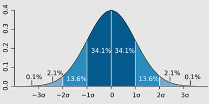

Figura 2: Escalas de desvio-padrão de uma distribuição normal

Uma consequência da distribuição normal é a de que essa pode ser compartimentada em escalas de desvio padrão, de forma que 1 desvio padrão para mais ou para menos no entorno da média recubra aproximadamente 68,2% de toda a distribuição. Aumentando a quantidade de desvios padrões, aumenta tal cobertura.

Assim, uma medida oportuna de ser verificada em inventários é *quantos erros padrões resultariam em um recobrimento de 95%?* Essa pergunta define dois conceitos importantíssimos da amostragem e de inventários florestais: Erro de Amostragem e Intervalo de Confiança.

O Erro de Amostragem $E$ é calculado como

$$E = t_{n-1; 1 - {\alpha \over 2}} . s_{\bar y}$$

Onde $t_{n-1; 1 - {\alpha \over 2}}$ é o valor da distribuição t-student com $n-1$ graus de liberdade que representa o quantil de significância $\alpha$;$s_{\bar y}$ é o erro padrão.

O valor $\alpha$ é chamado de nível de significância (ou erro Tipo I), e representa o complemento do nível de confiança, de forma que um nível de confiança 0,95 (95%) representará um nível de significância de 0,05, pois $0.95=1-\alpha$, logo $\alpha=1-0.95$.

Note que se $t=1$, então o erro de amostragem será aproximadamente equivalente a 68,2% da distribuição. Se $t=2$, será equivalente a aproximadamente 95,4%. A conferência com tabelas de probabilidade da distribuição t-student permite encontrar o valor exato de $t$ para que recubra exatos 95%. Tal valor sempre depende do tamanho da amostra $n$, pois a distribuição tem como parâmetro os graus de liberdade. Se $n$ for suficientemente grande, haverá convergência para a distribuição normal. Nesse caso, o valor para se chegar em 95% seria aproximadamente 1,96. Apesar de não obrigatório, é comum utilizar $\alpha=0.05$, e a literatura técnica quase sempre utiliza tal valor como referência.

O erro de amostragem $E$ também pode ser escrito na sua forma relativa $E\%$, calculado como a proporção do erro no entorno da média amostral.

$$E\% = {E \over \bar y} . 100$$

Onde $E\%$ representa o erro relativo.

Esse erro relativo $E\%$ é o principal critério de avaliação de inventários florestais, e normalmente não deve ultrapassar 10%. Essa precisão exigida por muitos órgãos ambientais para aceitar projetos que envolvam inventários florestais, tais quais inventários para supressão de áreas e projetos de manejo florestal sustentável (PMFS).

## 4.7 Intervalos de Confiança

Calculado o erro de amostragem, a próxima etapa é calcular o intervalo de confiança. Como já se sabe o valor de $E$ cujo desvio no entorno da média recobre 95% da distribuição, então agora basta encontrar os valores correspondentes na distribuição da seguinte forma

$$IC = P(\bar y - t_{n-1; 1 - {\alpha \over 2}} . s_{\bar y} \leq \bar Y \leq \bar y + t_{n-1 ; 1 - {\alpha \over 2}}) = 0.95$$

Onde $IC$ é o intervalo de confiança.

É percebível que o intervalo de confiança nada mais é que a soma ou subtração do erro de amostragem no entorno da média amostral. Para tornar a equação mais genérica, é possível trocar 0,95 por $1 - \alpha$. O raciocínio dessa abordagem é o de que não se sabe a verdadeira média paramétrica $\bar Y$, porém se for estipulado um intervalo que recobre digamos 95% de toda a distribuição, então existe uma probabilidade de 95% de que o intervalo contenha o valor paramétrico.

## 4.8 Suficiência e Intensidade Amostral

Outro resultado da teoria da amostragem e de caráter fundamental em inventários florestais é o cálculo da intensidade amostral. Seja o Erro Amostral $E$ elevado ao quadrado

$$E^2 = (t . s_{\bar y})^2$$

Aqui, $t$ é o quantil da distribuição t-student, será omitido o índice $n-1;1- \alpha/2$.

$$E^2 = (t . s_{\bar y})^2 = t^2 . s_{\bar y}^2 = t^2 . \hat V[\bar y] = t^2 {s^2 \over n} \left({N-n \over N} \right)$$

Perceba que o erro amostral $E$ é função do tamanho amostral $n$ e da variância da amostra $s^2$. Se resolvermos para $n$

$$E^2 = t^2 {s^2 \over n} \left( {N-n \over N} \right)$$

$$nNE^2 = t^2s^2N - t^2s^2n$$

$$nNE^2 + t^2s^2n = t^2s^2N$$

$$n(NE^2 + t^2s^2) = t^2s^2N$$

$$n = {t^2s^2N \over NE^2 + t^2s^2} = {t^2s^2N \over N\left( E^2 + {t^2s^2 \over N} \right)} = {t^2s^2 \over E^2 + {t^2s^2 \over N}}
\tag{6}$$

Teremos o tamanho da amostra resultante da variabilidade $s^2$ e o erro $E$ estabelecido. Portanto é possível encontrar o tamanho de amostra necessário para que se obtenha um erro $E$ pré-definido, e desde que se tenha uma estimativa de $s^2$ prévia ao inventário.

O valor de $s^2$ pode ser obtido preferencialmente por um inventário piloto, onde algumas parcelas de inventário são realizadas a campo e o inventário é processado. Caso nesse inventário piloto o erro de amostragem E tenha sido superior ao estipulado, então pode-se fazer uso do Resultado 6.

Note ainda que o Resultado 6 faz uso do erro de amostragem em termos absolutos, na escala da variável resposta, porém é possível utilizar a notação do erro relativo $E\%$ para delimitação de um erro relativo máximo

$$E = {E\% \bar y \over 100}$$

$$E^2 = \left({E\% \bar y \over 100} \right)^2 = {E\%^2 \bar y^2 \over 100^2} = {t^2s^2 \over n} \left({N-n \over N} \right)$$

$$E\%^2 = {t^2s^2.100^2 \over n \bar y^2} \left( {N-n \over N} \right)$$

Veja que ${s^2100^2 \over \bar y^2} = \left({s \over \bar y} . 100 \right)^2 = (CV\%)^2$, o coeficiente de variação de $y_i$ em porcentagem, portanto

$$E\%^2 = {t^2CV\%^2 \over n} \left({N-n\over N} \right)$$

$$nNE\%^2 = t^2 CV\%^2N - t^2CV\%^2n$$

$$n(NE\%^2 + t^2CV\%^2) = t^2CV\%^2N$$

$$n = {t^2CV\%^2N \over NE\%^2 + t^2CV\%^2} = {t^2 CV\%^2 \over E\%^2 + {t^2CV\%^2 \over N}}
\tag{7}$$

Quando a população é considerada infinita, os cálculos ficam muito mais simplificados

$$n = {t^2 s^2 \over E^2} = {t^2 CV\%^2 \over E\%^2}$$

Ainda outra maneira de determinar a intensidade amostral é utilizando um critério de custos. Para isso, autores como Péllico Netto & Brena (1997) apresentam uma função de custo em função do número de parcelas de inventário no desenho de ACS.

$$C = C_0 + C_1 . n$$

$$n = {C - C_0 \over C_1}$$

Onde $C$ é o custo total admitido, $C_0$ são os custos fixos e $C_1$ são os custos variáveis, que dependem do número de parcelas realizadas.

## 4.9 Outros Estimadores

Além da média e do total, existem também outras quantidades que se deseja conhecer na população, como a razão entre variáveis ou a proporção de ocorrência. A razão populacional entre variáveis é dada por

$$R = {\bar Y \over \bar X} = {{1 \over N} \displaystyle\sum_{i=1}^{N} y_i \over {1 \over N} \displaystyle\sum_{i=1}^{N} x_i } = { \displaystyle\sum_{i=1}^{N} y_i \over \displaystyle\sum_{i=1}^{N} x_i }$$

$$\hat R = {\bar y \over \bar x} = { \displaystyle\sum_{i=1}^{n} y_i \over \displaystyle\sum_{i=1}^{n} x_i }$$

Onde $y_i$ e $x_i$ são duas variáveis aleatórias, e $\hat R$ é o estimador de razão.

O estimador de razão é um exemplo de estimador viesado na quantidade de $1/n$, pois o estimador da variância assume que pelo menos $\bar X$ (valor populacional) seja conhecido, e a falta desse leva a um pequeno viés na estimativa. Ainda assim, o estimador de razão tem sido bastante empregado no Brasil para obtenção de estimativas confiáveis de biomassa florestal.

# 5 Amostragem Casual Estratificada

## 5.1 Introdução e Diferença em relação À ACS

É importante conhecer o funcionamento da ACS, bem como das propriedades dos seus estimadores, pois é a partir dessa que a maioria dos outros planos amostrais são construídos. Outro plano amostral recorrente na área florestal é a Amostragem Casual Estratificada, ou Amostragem Aleatória Estratificada.

Seja uma certa população de tamanho $N$. Na amostragem casual simples, as estimativas de média e variância são tomadas considerando toda a população, e, portanto, tratam toda a população como algo homogêneo. Mas considere agora que nessa população existem $L$ subpopulações (chamadas de estratos) de tamanho $N_1,N_2,\cdots,N_L$ tal que $N_1+N_2+\cdots+N_L=N$, e que que as unidades amostrais sejam homogêneas dentro de cada população.

Nesse raciocínio, cada estrato terá suas próprias quantidades em cada estrato, como $\bar Y_1, \bar Y_2$, etc., e ainda assim existirão valores populacionais, como $\bar Y$ e $S^2$. A diferença é que agora se pode levar em conta que na população existem regiões homogêneas, e isso pode reduzir consideravelmente a intensidade amostral. Como cada estrato é considerado homogêneo, então é possível aplicar a amostragem casual simples (ACS) em cada um desses estratos.

O primeiro ponto a ser entendido sobre amostragem estratificada é o peso que cada estrato possui na composição do todo. Isso pode ser percebido ao calcular a média populacional

$$\bar Y = { \displaystyle\sum_{h=1}^{L} \displaystyle\sum_{i=1}^{N_h} y_{hi} \over N} = { \displaystyle\sum_{h=1}^{L} N_h \bar Y_h \over N} = \displaystyle\sum_{h=1}^{L} {N_h \over N} \bar Y_h = \displaystyle\sum_{h=1}^{L} W_h \bar Y_h$$

Onde $N_h$ é o tamanho do $h$-ésimo estrato, $W_h$ é o peso associado ao estrato $h$. Demais variáveis já apresentadas.

## 5.2 Notação

Veja que a média populacional pode ser calculada como uma combinação linear das médias de cada estrato, ponderadas pelo seu respectivo peso $W_h={N_h\over N}$.

## 5.3 Média Amostral

Portanto o estimador para a média populacional pode ser escrito como

$$\bar y_{st} = { \displaystyle\sum_{h=1}^{L} N_h \bar y_h \over N} = \displaystyle\sum_{h=1}^{L} W_h \bar y_h$$

Onde $\bar y_{st}$ é o estimador da média populacional, chamada de **média estratificada**. $\bar y_h$ é a média amostral do estrato $h$.

Veja que $\bar y_{st}$ é não viesada, pois se cada estrato for amostrado como casual simples, então

$$E[\bar y_{st}] = \displaystyle\sum_{h=1}^{L} W_h E[\bar y_h] = \displaystyle\sum_{h=1}^{L} W_h \bar Y_h = \bar Y$$

Além disso, $\bar y_{st}$ difere da simples média aritmética das unidades amostrais ao longo de todos os estratos. Seja a média aritmética total denotada por $\bar y$, então

$$\bar y = { \displaystyle\sum_{h=1}^{L} n_h \bar y_h \over n}$$

Onde $n$ é o tamanho da amostra considerando todos os estratos; $n_h$ é o tamanho da amostra do $h$-ésimo estrato.

Veja que apenas $\bar y_{st}$, a média estratificada, recebe os pesos adequados para ser não viesado, $N_h \over N$ em vez de $n_h\over n$. Ainda assim, é evidente que $\bar y$ vai coincidir com $\bar y_{st}$ contanto que, para cada estrato

$${n_h \over n} = {N_h \over N} \qquad \text{ou} \qquad {n_h \over N_h} = {n \over N} \qquad \text{ou} \qquad f_h = f
\tag{8}$$

Onde $f_h$ é a fração amostral do $h$-ésimo estrato.

Em outras palavras, que a fração amostral é a mesma em todos os estratos. Um estrato com o dobro do tamanho, terá o dobro do número de amostras. Dessa construção, pode-se concluir que na amostragem casual estratificada, as quantidades de interesse são obtidas basicamente a partir de **médias ponderadas** das quantidades de cada estrato, e existe uma combinação de pesos (aquela proporcional ao tamanho do estrato), que garante um estimador não viesado para as quantidades populacionais.

A estratificação descrita no Resultado 8 é chamada de estratificação com **alocação proporcional**, pois cada estrato terá amostras $n_h$ proporcionais a seu próprio peso $N_h$ na população.

## 5.4 Variância da Média Amostral

Supondo que seja mantida a alocação proporcional, pode-se facilmente chegar na variância da média estratificada

$$V[\bar y_{st}] = V\left[ \displaystyle\sum_{h=1}^{L} W_h \bar y_{st} \right] = \displaystyle\sum_{h=1}^{L} W_h^2V[\bar y_h]
\tag{9}$$

**Prova:**

Como $\bar y_{st}$ é uma combinação linear de variáveis aleatórias com pesos fixos $W_h$, pode-se usar a variância de uma combinação linear, isto é,

$$V[\bar y_{st}] = \displaystyle\sum_{h=1}^{L} W_h^2V[\bar y_h] + 2 \displaystyle\sum_{h=1}^{L} \displaystyle\sum_{h<j} W_hW_j Cov(\bar y_h, \bar y_j)$$

Onde $Cov(\cdot)$ é a covariância entre duas variáveis aleatórias.

Entretanto, como as amostras são retiradas de forma independente em diferentes estratos, todas as covariâncias entre estratos são inexistentes. Isso resulta na expressão final. Veja que a variância da média de um estrato $V[\bar y_h]$ é exatamente a mesma expressão da ACS

$$V[\bar y_h] = {S^2_h \over n_h}(1 - f_h)$$

Ao substituir no Resultado 9, temos que

$$V[\bar y_{st}] = \displaystyle\sum_{h=1}^{L} W_h^2V[\bar y_h] = \displaystyle\sum_{h=1}^{L} W_h^2 {S^2_h \over n_h}(1-f_h)$$

Alguns casos particulares podem resultar em formulações mais fáceis. Por exemplo, se as frações $n_h\over N_h$ são mínimas, isto é, população infinita, então

$$V[\bar y_{st}] = {1 \over N^2} \displaystyle\sum_{h=1}^{L} {N_hS^2_h \over n_h} = \displaystyle\sum_{h=1}^{L} {W_h^2S^2_h \over n_h}$$

Se a alocação for proporcional ($f_h=f$), então podemos substituir

$$n_h = {nN_h \over N}$$

$$\begin{aligned}
V[\bar y_{st}] &= \displaystyle\sum_{h=1}^{L} {N_h^2 \over N^2} {S^2_h \over {nN_h \over N}} \left({N_h - {nN_h \over N} \over N} \right) \\
&= \displaystyle\sum_{h=1}^{L} {N_h \over N} {S^2_h \over n} \left( {NN_h - nN_h \over N^2} \right) = \\
&= \displaystyle\sum_{h=1}^{L} {N_h \over N} {S^2_h \over n} {N_h \over N^2} (N-n) = \displaystyle\sum_{h=1}^{L} {N^2_h \over N^3} {S^2_h \over n}(N-n) = \\
&= \displaystyle\sum_{h=1}^{L} {N_h^2 \over N^2} {S^2_h \over n} {(N-n) \over N} = \displaystyle\sum_{h=1}^{L} W^2_h {S^2_h \over n}(1-f) = \\
&= {1-f \over n} \displaystyle\sum_{h=1}^{L} W_h^2S^2_h
\end{aligned}$$

Por fim, pode-se ainda assumir alocação proporcional e que as variâncias de todos os estratos são iguais, $S^2_w$, o que resulta em

$$V[\bar y_{st}] = {S^2_w \over n} \left({N-n \over N} \right)$$

Que é o mesmo caso da amostragem aleatória simples. Esse resultado é intuitivo, pois se todos os estratos possuem mesma variância e a alocação é proporcional, então isso recairá a uma amostragem casual simples.

## 5.5 Variância da Amostra

Note que até o momento as variâncias paramétricas de cada estrato $S_h^2$ foram utilizadas, mas supondo que cada estrato foi amostrado como ACS, então um estimador não viesado e consistente para $S_h^2$ é $s_h^2$. Veja, no entanto, que é necessário que cada estrato possua uma amostra de pelo menos tamanho 2 ($n_h\geq2$).

E, portanto, um estimador não viesado para $V[\bar y_{st}]$ é

$$\hat V[\bar y_{st}] = \displaystyle\sum_{h=1}^{L} W_h^2 {s_h^2 \over n_h}(1-f_h)$$

## 5.6 Erro de Amostragem

Uma vez calculadas a média amostral e a sua estimativa da variância, é possível calcular o erro de amostragem. Para a amostragem estratificada também se assume que $\bar y_{st}$ possui distribuição normal, e como há substituição de $S_h^2$ pela estimativa da variância amostral $s_h^2$, também se segue com a alteração da distribuição para a distribuição t-student.

Entretanto, os graus de liberdade da distribuição t-student agora devem ser um valor que represente a proporção amostrada de cada estrato. Cochran (1977) atribui a Satterthwaite (1946) uma aproximação

$$\hat V[\bar y_{st}] = {1 \over N^2} \displaystyle\sum_{h=1}^{L} g_hs^2_h \qquad \text{onde} \qquad g_h = {N_h(N_h - n_h) \over n_h}$$

Então o número efetivo de graus de liberdade é dado por

$$n_e = { \left(\displaystyle\sum_{h=1}^{L} g_hs^2_h\right)^2 \over \displaystyle\sum_{h=1}^{L} {g^2_hs_h^4 \over n_h-1}}$$

Onde $n_e$ é o número efetivo de graus de liberdade a ser utilizado na distribuição t-student.

Com a obtenção do número efetivo de graus de liberdade, é possível criar os intervalos de confiança da mesma maneira que para ACS

$$E = t_{n_e; 1 - {\alpha/2}} . s_{\bar y_{st}}$$

Onde $s_{\bar y_{st}}$ é o erro padrão da média estratificada.

O intervalo de confiança é obtido de forma análoga.

$$IC = P\left( \bar y_{st} - t_{n_e; 1 - {\alpha \over 2}} . s_{\bar y_{st}} \leq \bar Y \leq \bar y_{st} + t_{n_e; 1 - {\alpha \over 2}} . s_{\bar y_{st}} \right) = 1 - \alpha$$

## 5.7 Suficiência e Intensidade Amostral

Caso o inventário não atinja a precisão requerida, é possível determinar a intensidade amostral para um dado erro tolerado, isto é, encontrar o valor de n apropriado. Na Amostragem Casual Estratificada (ACE), o tamanho total da amostra n pode ser obtido tal qual na ACS, com uma pequena modificação na composição da variância

$$n = {t^2 \displaystyle\sum_{h=1}^{L} W_h S^2_h \over E^2 + t^2 \displaystyle\sum_{h=1}^{L} {W_h S^2_h \over N}}$$

Mantendo-se a alocação proporcional, então basta aplicar a equação

$$n_h = {nN_h \over N}$$

Para se chegar no número de amostras de cada estrato. Embora a alocação proporcional seja o tipo de alocação canônica da média amostral, a quantidade de parcelas que serão alocadas em cada estrato é critério do engenheiro florestal responsável. Existem outras maneiras de realizar a alocação de parcelas, como por exemplo minimizando os custos para uma certa variância, ou então minimizar a variância para um determinado custo.

Sejam as fórmulas do custo $C$ e variância da média $V$

$$C = C_0 + \displaystyle\sum_{h=1}^{L} c_hn_h$$

$$V = V[\bar y_{st}] = \displaystyle\sum_{h=1}^{L} {W_h^2S_h^2 \over n_h}(1-f_h) = \displaystyle\sum_{h=1}^{L} {W_h^2S_h^2 \over n_h} - \displaystyle\sum_{h=1}^{L} {W_h^2S_h^2 \over N_h}$$

Onde $C_0$ é o custo fixo, e $c_h$ é o custo variável para execução de uma U.A. no $h$-ésimo estrato.

É possível observar que é possível minimizar o sistema acima aplicando a desigualdade de Cauchi-Schwarz, obtendo-se a seguinte relação (Vai ficar faltando uma prova aqui)

$${n_h \over n} \equiv {{W_hS_h \over \sqrt{c_h}} \over \displaystyle\sum_{h=1}^{L} {W_h S_h \over \sqrt{c_h}}} = {{N_hS_h \over \sqrt{c_h}} \over \displaystyle\sum_{h=1}^{L} {N_hS_h \over \sqrt{c_h}}}$$

Veja que da relação acima, pode-se concluir que um estrato terá maior número de U.A. se

1. O estrato for maior
2. Se o estrato possui maior variabilidade interna
3. Se a amostragem é mais barata no estrato

O resultado acima vale tanto para minimização do custo para uma dada variância, bem como minimização da variância para um dado custo. Entretanto, o resultado acima só retorna a proporção da amostra que será coletada no estrato $h$. Ainda é necessário encontrar o tamanho da amostra n. Para um *custo fixado*, o tamanho $n$ que minimiza a variância será

$$n = {(C - C_0) \displaystyle\sum_{h=1}^{L} {N_hS_h \over \sqrt{c_h}} \over \displaystyle\sum_{h=1}^{L} {N_h S_h \over \sqrt{c_h}}}$$

Caso exista uma *variância fixada*, o tamanho de amostra que minimiza o custo é

$$n = {\left( \displaystyle\sum_{h=1}^{L} {W_h S_h \over \sqrt{c_h}} \right) \displaystyle\sum_{h=1}^{L} W_hS_h\sqrt{c_h} \over {V + ({1 \over N}) \displaystyle\sum_{h=1}^{L} W_hS_h^2}}$$

Por fim, um outro resultado importante é se $c_h=c$, isto é, os custos por unidade amostrada são os mesmos em todos os estratos. O custo se torna $C=c_0+c.n$, e o resultado se simplifica para

$$n_h = n{W_h S_h \over \displaystyle\sum_{h=1}^{L} W_hS_h} = n{N_hS_h \over \displaystyle\sum_{h=1}^{L} N_hS_h}$$

O resultado acima é chamado de **alocação ótima de Neyman**.

## 5.8 Outros Estimadores

Avaliando os dois desenhos de amostragem apresentados, ACS e ACE, percebe-se que, caso a área seja considerada homogênea, ou caso não exista motivo para considerar diferentes estratos na população, então a amostragem aleatória simples é o caminho natural a ser seguido. Como apresentado, o caso limite onde todos os estratos possuem a mesma variabilidade recai sobre uma amostragem casual simples.

Por outro lado, no caso da existência de regiões heterogêneas entre si, a amostragem estratificada resulta em estimativas mais precisas, *i.e.*, com menor erro padrão. Sejam as variâncias obtidas via amostragem aleatória simples ($V_{ACS}$), estratificada com alocação proporcional ($V_{prop}$) e estratificada com alocação ótima ($V_{OPT}$), então realizando algumas flexibilizações, Cochran (1977) chegou nos seguintes resultados

$$V_{ACS} = V_{OPT} + {1 \over n} \displaystyle\sum_{h=1}^{L} W_h(S_h - \bar S)^2 + {1 - f \over n} \displaystyle\sum_{h=1}^{L} W_h(\bar Y_h - \bar Y)^2$$

$$V_{ACS} = V_{prop} + {1 - f \over n(N-1)} \left[ \displaystyle\sum_{h=1}^{L} N_h(\bar Y_h - \bar Y)^2 - {1 \over N} \displaystyle\sum_{h=1}^{L} (N - N_h)S^2_h\right]$$

Ou seja, se existir diferença entre estratos, então $V_{ACS} \geq V_{OPT}$ ou $V_{ACS} \geq V_{prop}$, o que prova que a amostragem estratificada fornece estimativas mais precisas que a ACS.

# 6 Novas Tecnologias

## 6.1 Onde Melhorar

A Amostragem Aleatória Simples (ACS) continua sendo uma das bases metodológicas mais utilizadas nos inventários florestais. No entanto, nos últimos anos, avanços tecnológicos têm proporcionado melhorias substanciais na sua aplicação, tanto na coleta quanto no processamento dos dados.

Na coleta de dados, o uso de softwares móveis como o Mata Nativa permite realizar medições e cálculos em campo com mais agilidade e segurança. Esses aplicativos integram GPS, banco de dados e ferramentas estatísticas, favorecendo o rigor na seleção aleatória das unidades amostrais e facilitando o controle da amostragem durante a execução do inventário.

Além disso, dispositivos com sensores avançados, como drones equipados com LiDAR, têm sido incorporados aos inventários para mapear previamente a área de estudo. Isso possibilita uma estratificação mais refinada, identificação de áreas de acesso difícil e, em alguns casos, até a substituição parcial da coleta de campo, otimizando tempo e recursos.

No processamento dos dados, ferramentas como o Katam™ Forest automatizam a análise e a estimativa de variáveis dendrométricas, como altura e diâmetro, a partir de imagens capturadas em campo ou por sensores remotos. Junto disso, modelos de regressão mais sofisticados e o uso de aprendizado de máquina têm permitido reduzir o erro amostral e aumentar a precisão dos estimadores derivados da ACS.

Essas inovações, embora não alterem o fundamento estatístico da ACS, que permanece baseado na seleção equiprovável das unidades, ampliam sua aplicabilidade e eficiência operacional, tornando-a mais robusta frente às exigências técnicas e logísticas dos inventários florestais modernos.

# 7 Conclusão

A compreensão aprofundada dos fundamentos estatísticos da Amostragem Casual Simples (ACS) e da Amostragem Casual Estratificada (ACE) é essencial para o planejamento e a execução de inventários florestais com rigor técnico e eficiência. A ACS, por sua simplicidade conceitual e operacional, constitui a base sobre a qual os demais planos são construídos. Já a ACE, ao incorporar informações estruturais da população por meio da estratificação, permite ganhos substanciais em precisão, especialmente em cenários de alta heterogeneidade espacial.

O desenvolvimento formal de estimadores não viesados, suas variâncias e respectivas estimativas, bem como a incorporação de distribuições de probabilidade para fins de inferência, demonstram como a Teoria da Pesquisa por Amostragem (TPA) oferece soluções exatas e robustas mesmo para populações finitas. Além disso, a consideração de diferentes métodos de alocação e intensidade amostral torna o planejamento mais flexível e ajustado às condições do levantamento.

Adicionalmente, a incorporação de tecnologias emergentes, como sensores remotos, inteligência artificial e aplicativos móveis, tem potencializado a aplicação prática desses planos, agregando velocidade, acurácia e adaptabilidade aos inventários. O uso dessas ferramentas, aliado à fundamentação estatística rigorosa, representa um avanço significativo na capacidade de diagnosticar e manejar com responsabilidade os recursos florestais.

Portanto, o domínio dos aspectos teóricos e práticos dos planos de amostragem aqui apresentados representa um alicerce indispensável para engenheiros florestais e profissionais envolvidos em mensurações de campo, contribuindo não apenas para a eficiência dos inventários, mas também para a sustentabilidade na gestão florestal.

# 8 Bibliografia

COCHRAN, W.G. **Sampling techniques**. john wiley & sons, 1977.

PELLICO NETO, S.; BRENA, D.A. **Inventário florestal**. Curitiba: [s.l.]: 1997. 316 p.

QUEIROZ, W.T. **Amostragem em Inventário Florestal**. Belém, PA: EDUFRA, 2012, 441 p.